# Sensitivity of hurricanes to ocean heat

Last week you learned the difference between potential intensity and limiting intensity.

In short, **potential intensity** is the theoretical limit to how strong a hurricane can get given how warm the ocean under it is.

**Limiting intensity** is the statistical limit to how strong a hurricane can get.

### Sensitivity of hurricanes to ocean heat

In this lesson you will learn:

- How we can use limiting intensity to work out just how sensitive hurricanes are to rising ocean temperatures.

This is important because oceans are getting hotter.

### Limiting Intensity (LI)

As described last time limiting intensity is defined statistically. Suppose we record the highest wind speed (m/s) from ten consecutive hurricanes.

- 34.5, 44.2, 57.5, 33.8, 67.8, 38.2, 41.5, 71.2, 61.0, 49.1

We order the values from lowest to highest.

- 33.8, 34.5, 38.2, 41.5, 44.2, 49.1, 57.5, 61.0, **67.8**, **71.2**

Thus 20% of the hurricanes have winds exceeding 61 m/s and 10% have winds exceeding 67.8 m/s. We can use these quantile wind speeds to work out a highest possible wind speed. We call this the **limiting intensity (LI)**.

### Limiting Intensity (LI)

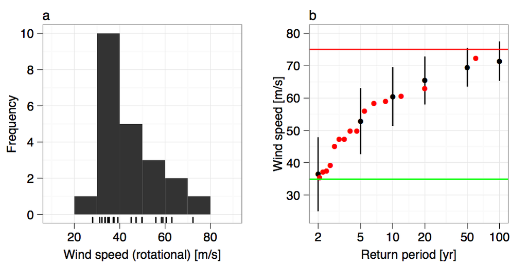

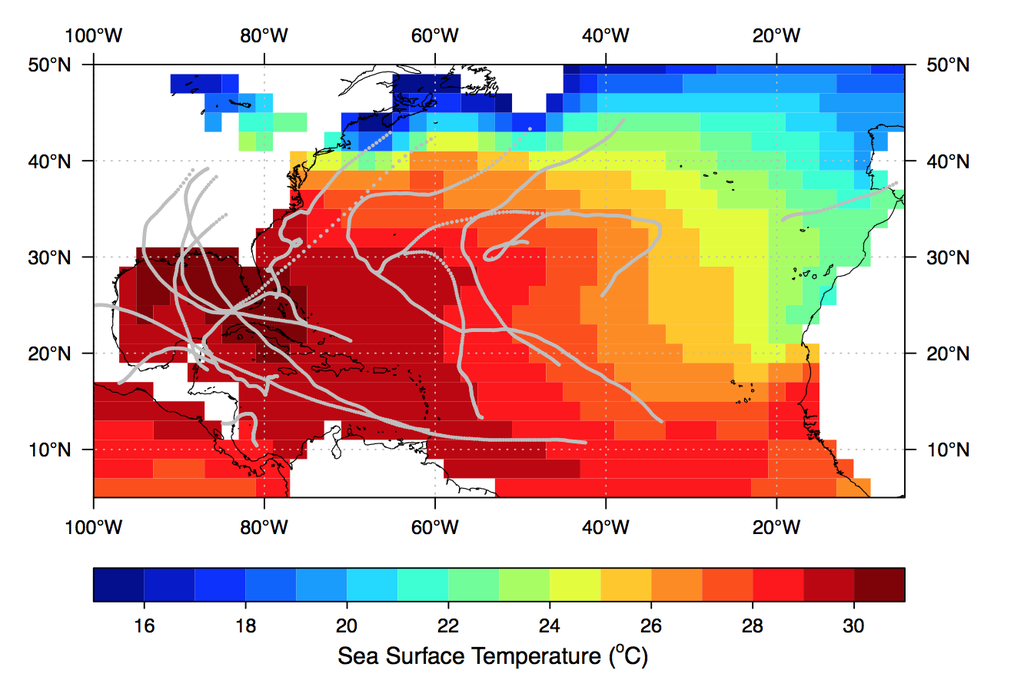

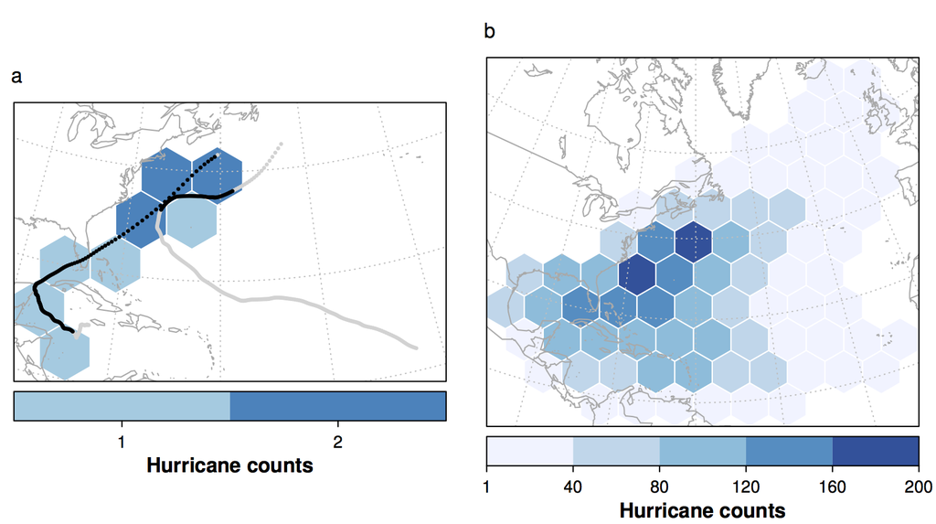

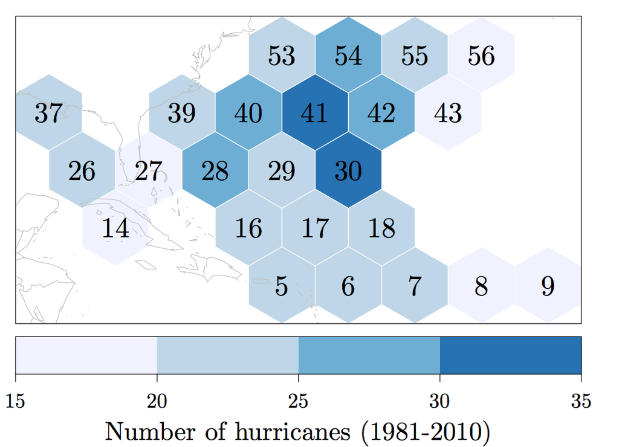

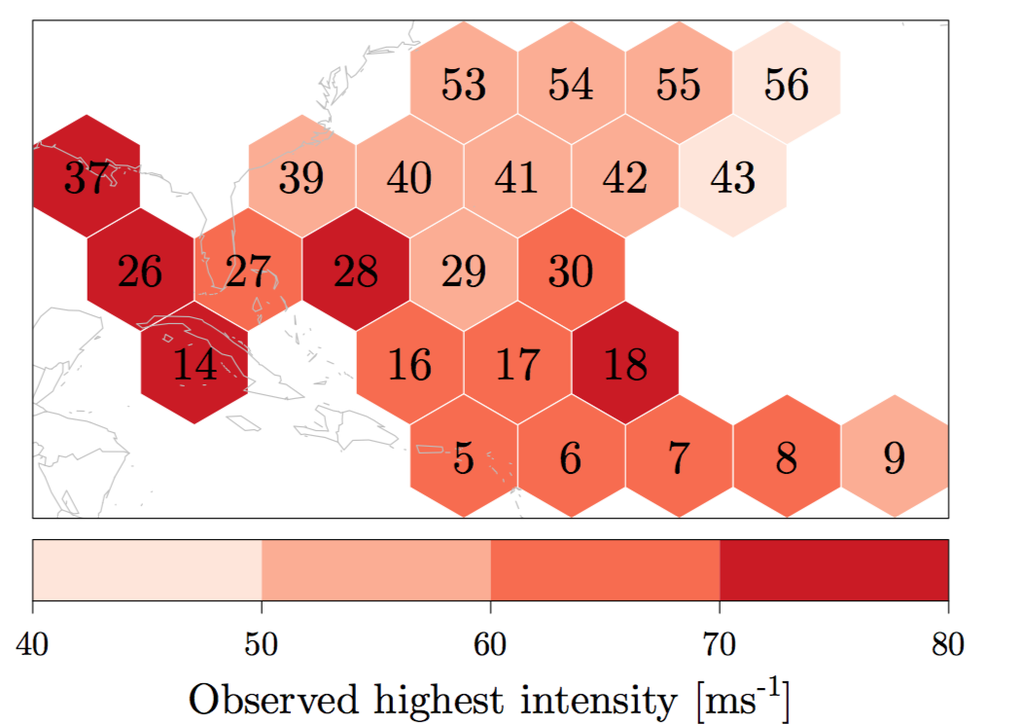

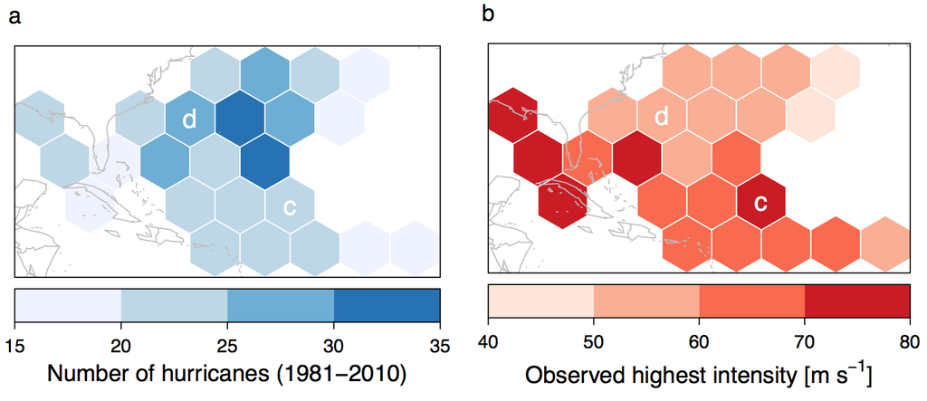

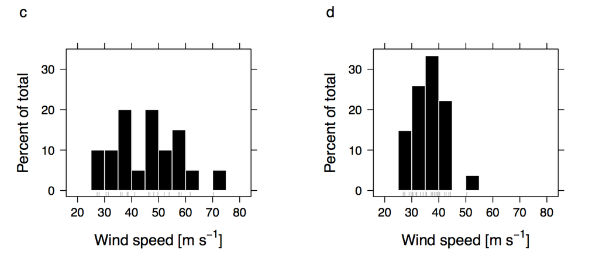

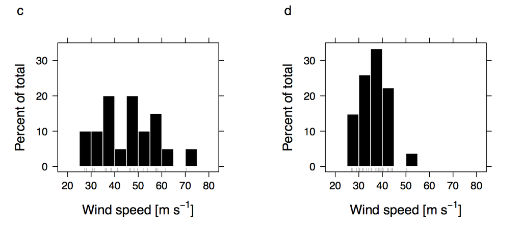

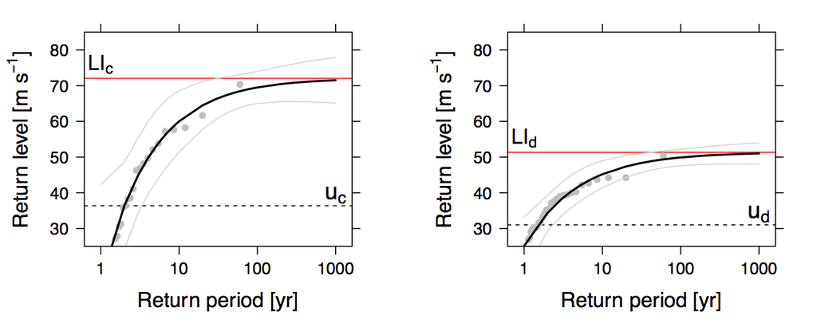

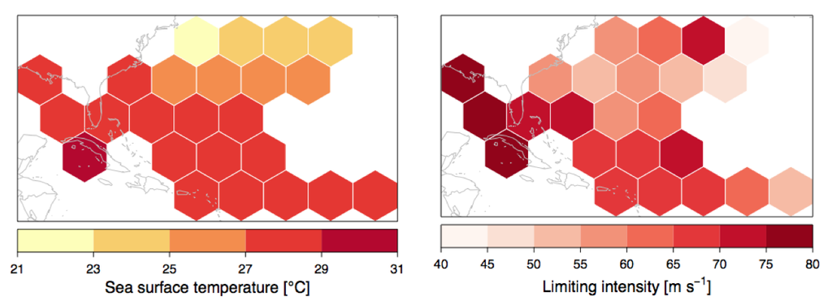

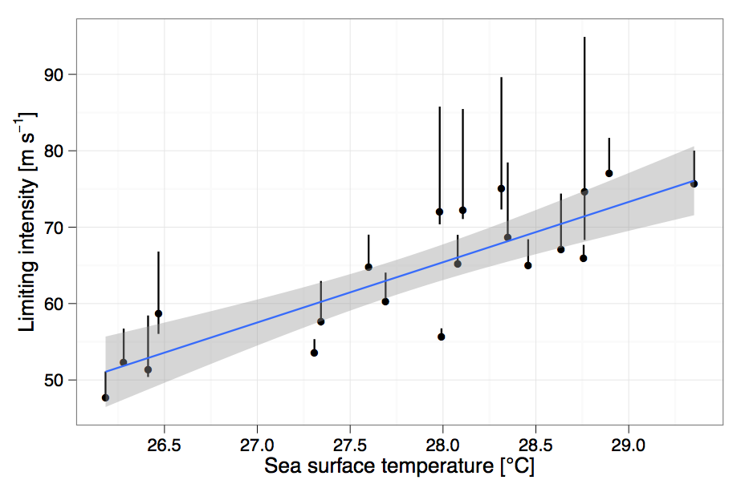

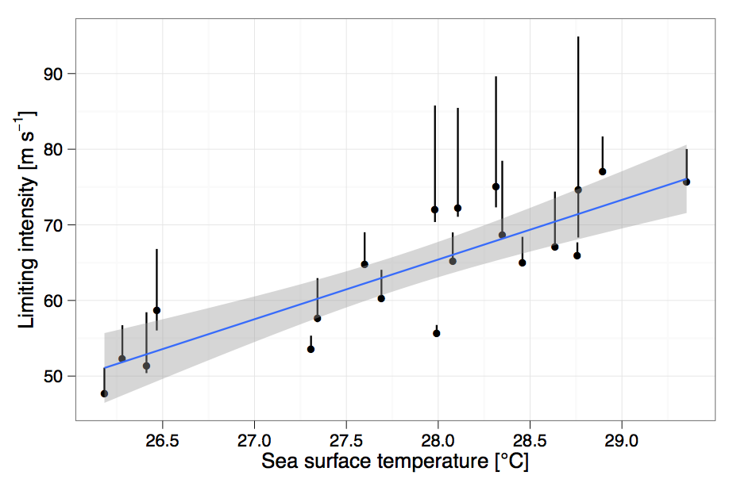